# R for Data Science

중요! 4. How does the average delay time change over the course of a day? Should you use dep_time or sched_dep_time? Why?

We should use sched_dep_time because it will tell us how much delay we should expect at the scheduled departure time. Also, using dep_time will always bias delays to later in the day since delays will push flights later.

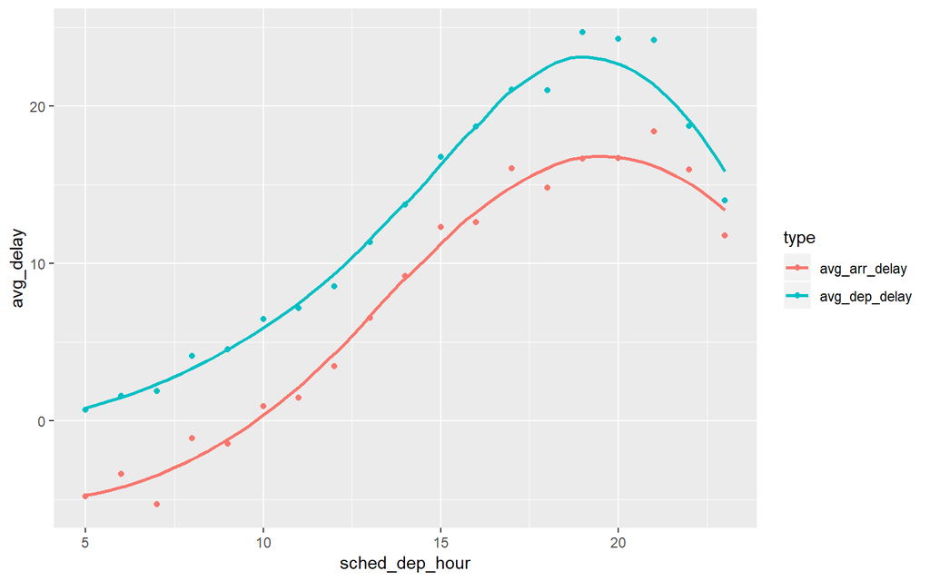

```r
flights_dt %>%
  mutate(sched_dep_hour = hour(sched_dep_time)) %>%
  group_by(sched_dep_hour) %>%
  summarise(avg_dep_delay = mean(dep_delay, na.rm = TRUE),
            avg_arr_delay = mean(arr_delay, na.rm = TRUE)) %>%   gather(key = type, value = avg_delay, -sched_dep_hour) %>%
  ggplot(aes(sched_dep_hour, avg_delay, color = type)) +
    geom_point() +
  geom_smooth(se = FALSE)
```

5. On what day of the week should you leave if you want to minimize the chance of a delay?

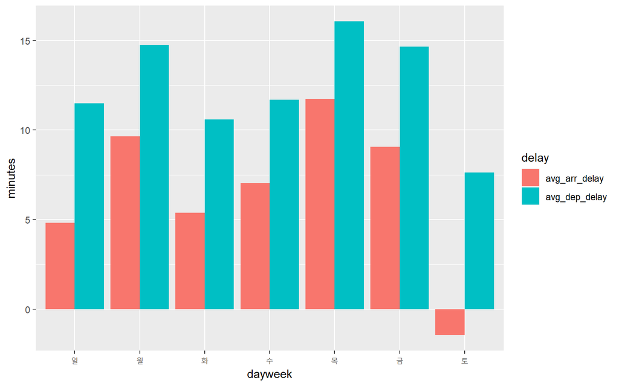

```r
flights_dt %>%
  mutate(dayweek = wday(sched_dep_time, label = TRUE)) %>%
  group_by(dayweek) %>%
  summarize(avg_dep_delay = mean(dep_delay, na.rm = TRUE),
            avg_arr_delay = mean(arr_delay, na.rm = TRUE)) %>%
  gather(key = 'delay', value = 'minutes', 2:3) %>%
  ggplot() +
  geom_col(mapping = aes(x = dayweek, y = minutes, fill = delay),
           position = 'dodge')
```

6. What makes the distribution of diamonds$carat and flights $sched_dep_time similar?

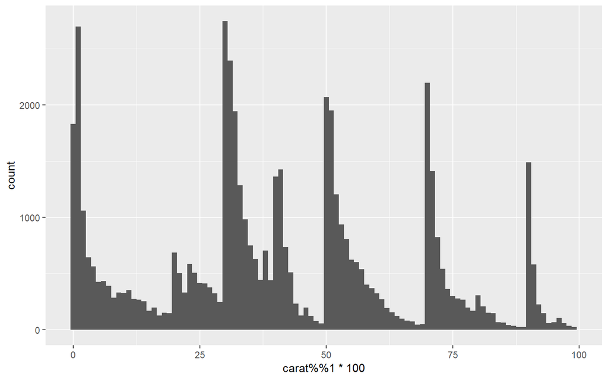

```r
ggplot(diamonds, aes(carat %% 1 * 100)) +
  geom_histogram(binwidth = 1)
```

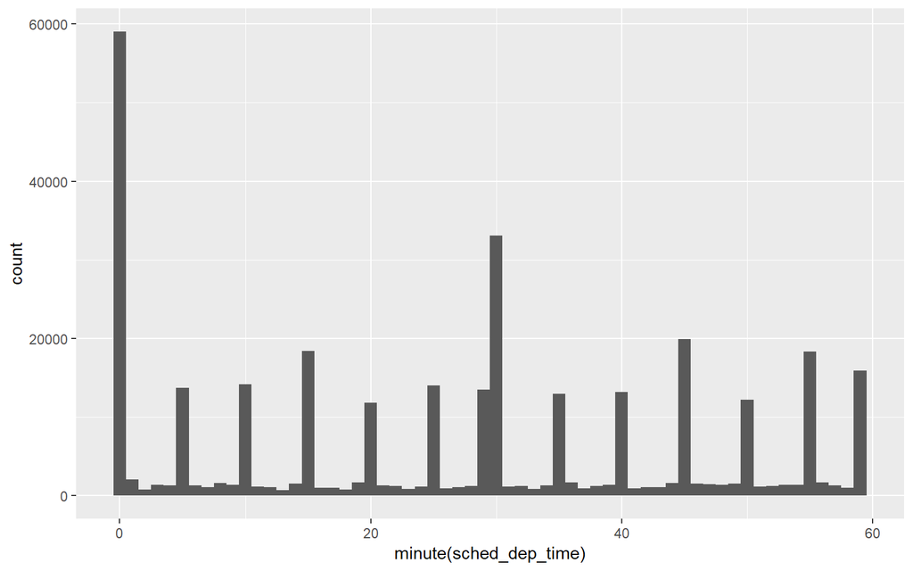

```r
ggplot(flights_dt, aes(x = minute(sched_dep_time))) +
  geom_histogram(binwidth = 1)
```

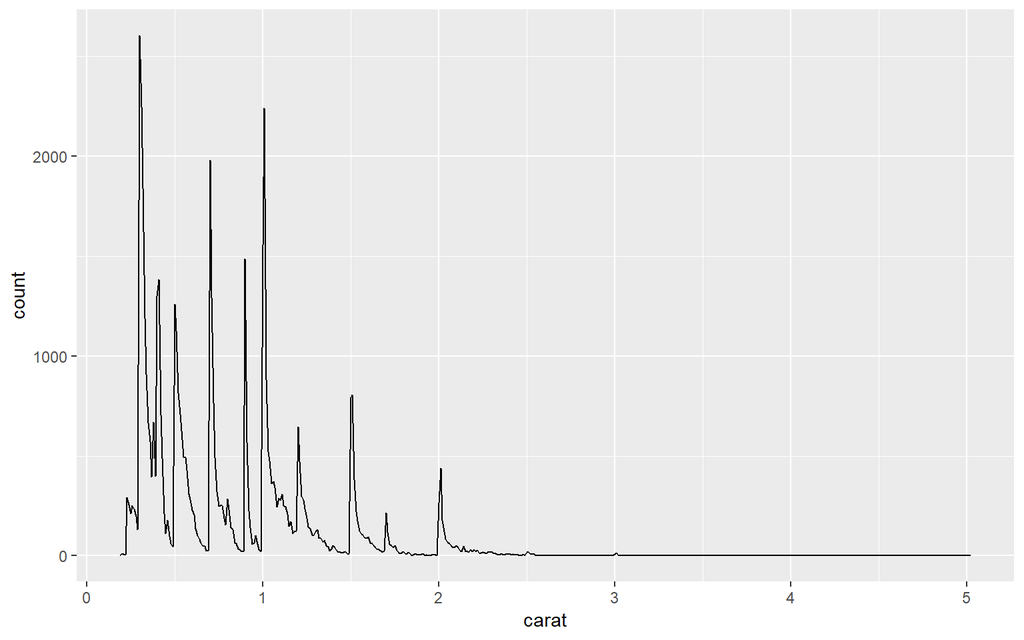

```r
ggplot(diamonds, aes(carat)) +
  geom_freqpoly(binwidth = 0.01)
```

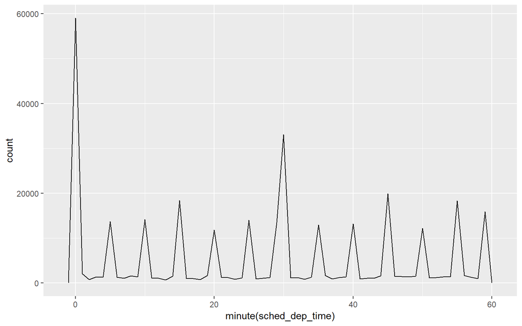

```r
ggplot(flights_dt, aes(minute(sched_dep_time))) +
  geom_freqpoly(binwidth = 1)
```

As the book suggests, these are most likely cuased by human factors, namely the convenience in representing nice, rounded numbers.

7. Confirm my hypothesis that the early departures of flights in minutes 20–30 and 50–60 are caused by scheduled flights that leave early. Hint: create a binary variable that tells you whether or not a flight was delayed.

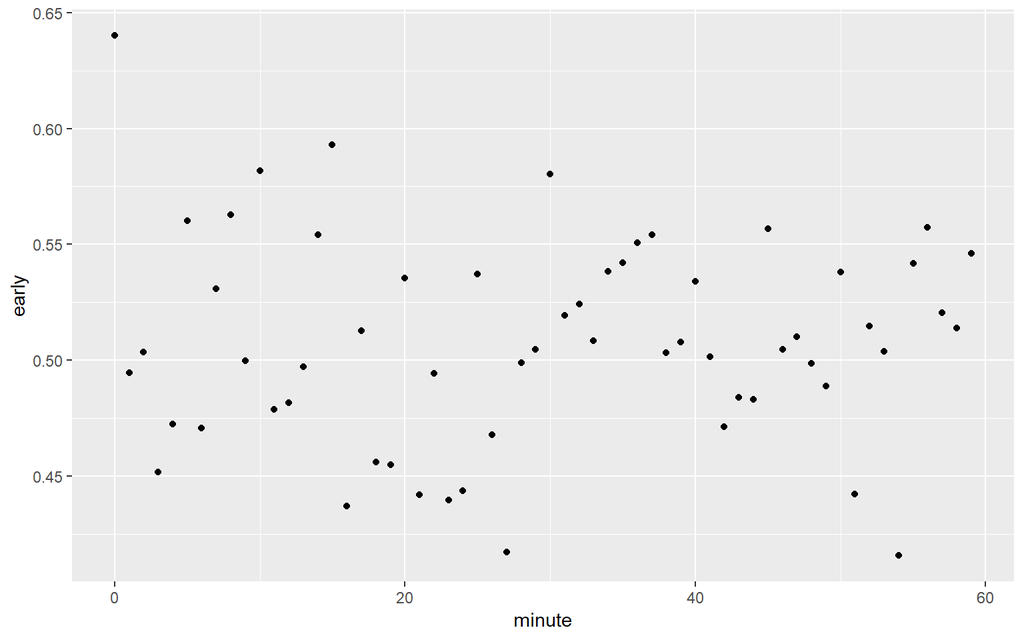

```r
# 특징이 없어 보인다.
flights_dt %>%
  mutate(early = dep_delay < 0,
         minute = minute(sched_dep_time)) %>%
  group_by(minute) %>%
  summarise(early = mean(early)) %>%
  ggplot(aes(x = minute, y = early)) +
  geom_point()
```

%/%와 %%를 혼동하지 말자.

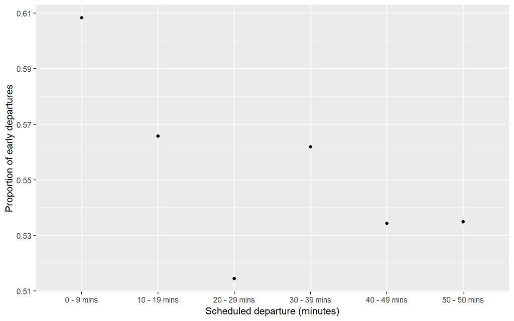

```r
flights_dt %>%
  mutate(early = dep_delay < 0,
         minutes = minute(sched_dep_time) %/% 10 * 10,
          minutes = factor(minutes, levels = c(0,10,20,30,40,50),
                            labels = c("0 - 9 mins",
                                       "10 - 19 mins",
                                       "20 - 29 mins",
                                       "30 - 39 mins",
                                       "40 - 49 mins",
                                       "50 - 50 mins"))) %>%
  group_by(minutes) %>%
  summarise(early = mean(early)) %>%
  ggplot(aes(minutes, early)) +
  geom_point() +
  labs(x = 'Scheduled departure (minutes)',
         y = 'Proportion of early departures')
```

## 2.5 Time Spans

뺄셈, 덧셈, 나눗셈을 포함한 날짜의 작동 알고리즘을 학습한다.

- *Durations*, 초의 정확한 수
- *Periods*, 주와 달 같은 human unit
- *Intervals*, 시작과 끝점

### 2.5.1 Durations

R에서, 두 날짜를 빼면, difftime object를 얻는다.

```r
# How old is Hadley?
h_age <- today() - ymd(19791014)
h_age
```

```
## Time difference of 14168 days
```

difftime class object는 초, 분, 시간, 날, 주의 기간을 기록한다. 이런 애매모호함은 difftime을 약간 작업하기 힘들게 만들어서 lubridate는 항상 초를 사용해서 대안을 제공한다.

```r
as.duration(h_age)
```

```
## [1] "1224115200s (~38.79 years)"
```

```r
dseconds(15)
```

```
## [1] "15s"
```

```r
dminutes(10)
```

```
## [1] "600s (~10 minutes)"
```

```r
dhours(c(12, 24))
```

```
## [1] "43200s (~12 hours)" "86400s (~1 days)"
```

```r
ddays(0:5)
```

```
## [1] "0s"                "86400s (~1 days)"  "172800s (~2 days)"
## [4] "259200s (~3 days)" "345600s (~4 days)" "432000s (~5 days)"
```

```r
dweeks(3)
```

```
## [1] "1814400s (~3 weeks)"
```

```r
dyears(1)
```

```
## [1] "31536000s (~52.14 weeks)"
```

duration은 항상 초로 기간을 기록한다. 큰 단위는 분, 시간, 날, 주, 년으로 변환된다.

duration을 더하고 곱할 수 있다.

```r
2 * dyears(1)
```

```
## [1] "63072000s (~2 years)"
```

```r
dyears(1) + dweeks(12) + dhours(15)
```

```
## [1] "38847600s (~1.23 years)"
```

날들로 부터 duration을 더하거나 뺄 수 있다.

```r
tomorrow <- today() + ddays(1)
last_year <- today() - dyears(1)
```

하지만, duration은 정확한 초를 나타내기 때문에, 예기치 못한 결과를 얻을 수 있다.

```r
one_pm <- ymd_hms(
  "2016-03-12 13:00:00",
  tz = "America/New_York"
)
one_pm
```

```
## [1] "2016-03-12 13:00:00 EST"
```

```r
one_pm + ddays(1)
```

```
## [1] "2016-03-13 14:00:00 EDT"
```

DST때문에 3월12일은 23시간만 존재하기 때문에, 초의 완전한 날을 더하고자 한다면 다른 시간을 가져와야 한다.

### 2.5.2 Periods

함수들 뒤에 s가 붙는다는 것에 주의. 이 문제를 해결하기 위해, lubridate는 *perids*을 제공한다. Periods는 기간이지만 초의 고정된 길이를 가지지 않는다. 날과 달 같은 “human” 시간으로 작업하는 대신에. 좀 더 직관적인 방식으로 작업하게끔 한다.

```r
one_pm
```

```
## [1] "2016-03-12 13:00:00 EST"
```

```r
one_pm + days(1)
```

```
## [1] "2016-03-13 13:00:00 EDT"
```

duration과 같이 periods도 다수의 생성자 함수로 만들어진다.

```r
seconds(15)
```

```
## [1] "15S"
```

```r
minutes(10)
```

```
## [1] "10M 0S"
```

```r
hours(c(12, 24))
```

```
## [1] "12H 0M 0S" "24H 0M 0S"
```

```r
days(7)
```

```
## [1] "7d 0H 0M 0S"
```

```r
months(1:6)
```

```
## [1] "1m 0d 0H 0M 0S" "2m 0d 0H 0M 0S" "3m 0d 0H 0M 0S" "4m 0d 0H 0M 0S"
## [5] "5m 0d 0H 0M 0S" "6m 0d 0H 0M 0S"
```

```r
weeks(3)
```

```
## [1] "21d 0H 0M 0S"
```

```r
years(1)
```

```
## [1] "1y 0m 0d 0H 0M 0S"
```

periods에 더하거나 곱할 수 있다

```r
10 * (months(6) + days(1))
```

```
## [1] "60m 10d 0H 0M 0S"
```

```r
days(50) + hours(25) + minutes(2)
```

```
## [1] "50d 25H 2M 0S"
```

durations과 비교해서, periods는 제대로 작동

```r
# A leap year
ymd("2016-01-01") + dyears(1)
```

```
## [1] "2016-12-31"
```

```r
ymd("2016-01-01") + years(1)
```

```
## [1] "2017-01-01"
```

비행날짜와 관련된 이상한 것을 periods를 사용해 수정하자. 몇몇의 비행기는 뉴욕에서 출발하기 전에 목적지에 도착한 것 처럼 보인다.

```r
flights_dt %>%
  filter(arr_time < dep_time)
```

```
## # A tibble: 10,633 x 9
##    origin dest  dep_delay arr_delay dep_time            sched_dep_time
##    <chr>  <chr>     <dbl>     <dbl> <dttm>              <dttm>
##  1 EWR    BQN           9        -4 2013-01-01 19:29:00 2013-01-01 19:20:00
##  2 JFK    DFW          59        NA 2013-01-01 19:39:00 2013-01-01 18:40:00
##  3 EWR    TPA          -2         9 2013-01-01 20:58:00 2013-01-01 21:00:00
##  4 EWR    SJU          -6       -12 2013-01-01 21:02:00 2013-01-01 21:08:00
##  5 EWR    SFO          11       -14 2013-01-01 21:08:00 2013-01-01 20:57:00
##  6 LGA    FLL         -10        -2 2013-01-01 21:20:00 2013-01-01 21:30:00
##  7 EWR    MCO          41        43 2013-01-01 21:21:00 2013-01-01 20:40:00
##  8 JFK    LAX          -7       -24 2013-01-01 21:28:00 2013-01-01 21:35:00
##  9 EWR    FLL          49        28 2013-01-01 21:34:00 2013-01-01 20:45:00
## 10 EWR    FLL          -9       -14 2013-01-01 21:36:00 2013-01-01 21:45:00
## # ... with 10,623 more rows, and 3 more variables: arr_time <dttm>,
## #   sched_arr_time <dttm>, air_time <dbl>
```

이것들은 overnight flights이다. 출발과 도착 시간 둘 다 동일한 날짜 정보를 사용했지만, 이 항공편들은 다음 날에 도착한다. days(1)을 추가함으로써 고칠 수 있다.

```r
flights_dt <- flights_dt %>%
  mutate(
    overnight = arr_time < dep_time,
    arr_time = arr_time + days(overnight * 1), # 1을 곱해줘야 수치형으로 변환
    sched_arr_time = sched_arr_time + days(overnight * 1)
  )
```

```r
flights_dt %>%
  filter(overnight, arr_time < dep_time)
```

```
## # A tibble: 0 x 10
## # ... with 10 variables: origin <chr>, dest <chr>, dep_delay <dbl>,
## #   arr_delay <dbl>, dep_time <dttm>, sched_dep_time <dttm>,
## #   arr_time <dttm>, sched_arr_time <dttm>, air_time <dbl>, overnight <lgl>
```

### 2.5.3 Intervals

dyears(1) / ddays(365)가 1을 반환한다는 건 명백하다. 초의 수를 반환하기 때문에

years(1) / days(1)는 무엇을 반환할까? 2015년은 365를, 2016은 366을 반환한다.

```r
years(1) / days(1)
```

```
## estimate only: convert to intervals for accuracy
```

```
## [1] 365.25
```

좀 더 정확한 수치를 원한다면, *interval*을 사용하라. interval은 시작점이 있는 duration이다.

`%--%` Creates an interval that covers the range spanned by two dates. It replaces the original behavior of lubridate, which created an interval by default whenever two date-times were subtracted.

시작시간 %–% 끝시간

```r
# 함수몸체 확인
body("%--%")
```

```
## interval(start, end)
```

```r
next_year <- today() + years(1)
(today() %--% next_year) / ddays(1)
```

```
## [1] 365
```

얼마나 많은 periods가 interval로 나뉘는지 알기 위해, 몫연산 사용

```r
(today() %--% next_year) %/% days(1)
```

```
## Note: method with signature 'Timespan#Timespan' chosen for function '%/%',
##  target signature 'Interval#Period'.
##  "Interval#ANY", "ANY#Period" would also be valid
```

```
## [1] 365
```

### 2.5.4 Summary

물리적 시간 : duration human times : period human unit에서 기간 : interval

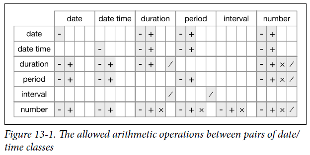

## 2.6 Exercises

1. Why is there months() but no dmonths()?

Why is there months() but no dmonths()?

There is no direct unambiguous value of months in seconds since months have differing numbers of days.

31 days: January, March, May, July, August, October 30 days: April, June, September, November, December 28 or 29 days: February

Though in the past, in the pre-computer era, for arithmetic convenience, bankers adopted a 360 day year with 30 day months.

2. Create a vector of dates giving the first day of every month in 2015. Create a vector of dates giving the first day of every month in the current year.

```r
ymd("2015-01-01") + months(0:11)
```

```
##  [1] "2015-01-01" "2015-02-01" "2015-03-01" "2015-04-01" "2015-05-01"
##  [6] "2015-06-01" "2015-07-01" "2015-08-01" "2015-09-01" "2015-10-01"
## [11] "2015-11-01" "2015-12-01"
```

```r
ymd(str_c(year(today()), "-", "01-01")) + months(0:11)
```

```
##  [1] "2018-01-01" "2018-02-01" "2018-03-01" "2018-04-01" "2018-05-01"
##  [6] "2018-06-01" "2018-07-01" "2018-08-01" "2018-09-01" "2018-10-01"
## [11] "2018-11-01" "2018-12-01"
```

```r
floor_date(today(), unit = "year") + months(0:11)
```

```
##  [1] "2018-01-01" "2018-02-01" "2018-03-01" "2018-04-01" "2018-05-01"
##  [6] "2018-06-01" "2018-07-01" "2018-08-01" "2018-09-01" "2018-10-01"
## [11] "2018-11-01" "2018-12-01"
```

3. Write a function that, given your birthday (as a date), returns how old you are in years.

```r
my_age <- function(date) {
  (ymd(date) %--% today()) %/% years(1)
}
my_age("1995-06-21")
```

```
## [1] 23
```

참고로 dyears(1)과 years(1)을 나눌 때 결과가 다르다.

## 2.7 Time Zones

첫번째 어려움은 시간대의 매일의 이름이 애매모호하다. 예를 들어, 미국인은 EST(Estern Standard Time)에 익숙하다. 하지만 오스트레일리아와 케나다 또한 EST를 가지고 있다. 혼란을 피하기 위해, R은 국제 표준 IANA 시간대를 사용한다. 이것은 “/”로 일관성 있는 명명 체계를 사용한다. “/” (대륙에 있지 않은 나라때문에 몇가지 예외가 있다.) “America/New_York,” “Europe/Paris,” and “Pacific/Auckland.”

시간대가 도시 이름을 포함하는 이유는 국가명은 시간이 지나면 변했지만 도시는 상대적으로 변하지 않았다.

또 다른 문제는 이름이 현재 행동 뿐만이 아니라 완전한 역사를 반영한다는 것이다. 예를 들어, “America/New_York” and “America/ Detroit.” 둘 다 현재는 EST를 사용하지만 1969-1972년에 미시간은 DST를 따르지 않아서 다른 이름이다.

```r
Sys.timezone() # R이 모른다면 NA
```

```
## [1] "Asia/Seoul"
```

모든 시간대의 완전한 리스트를 보고싶다면

```r
length(OlsonNames())
```

```
## [1] 592
```

```r
head(OlsonNames())
```

```
## [1] "Africa/Abidjan"     "Africa/Accra"       "Africa/Addis_Ababa"
## [4] "Africa/Algiers"     "Africa/Asmara"      "Africa/Asmera"
```

R에서 시간대는 프린팅을 조정할 수 있는 date-time의 속성이다. 다음 세개의 객체는 같은 시간을 나타낸다.

```r
(x1 <- ymd_hms("2015-06-01 12:00:00", tz = "America/New_York"))
```

```
## [1] "2015-06-01 12:00:00 EDT"
```

```r
(x2 <- ymd_hms("2015-06-01 18:00:00", tz = "Europe/Copenhagen"))
```

```
## [1] "2015-06-01 18:00:00 CEST"
```

```r
(x3 <- ymd_hms("2015-06-02 04:00:00", tz = "Pacific/Auckland"))
```

```
## [1] "2015-06-02 04:00:00 NZST"
```

```r
x1 - x2
```

```
## Time difference of 0 secs
```

```r
x1 - x3
```

```
## Time difference of 0 secs
```

명시하지 않는다면, lubridate는 항상 UTC를 사용한다. 이것은 DST를 가지지 않아서 계산을 편리하게 한다. c()와 같은 조합하는 연산은 종종 시간대를 제거한다.

```r
x4 <- c(x1, x2, x3)
x4
```

```
## [1] "2015-06-01 12:00:00 EDT" "2015-06-01 12:00:00 EDT"
## [3] "2015-06-01 12:00:00 EDT"
```

시간대를 두가지 방법으로 바꿀 수 있다.

- 시간을 같게 유지하고 어떻게 출력되는지 변경한다. 시간이 올바를 때 사용하고 좀 더 자연스럽게 출력하려면

```r
x4a <- with_tz(x4, tzone = "Australia/Lord_Howe")
x4a
```

```
## [1] "2015-06-02 02:30:00 +1030" "2015-06-02 02:30:00 +1030"
## [3] "2015-06-02 02:30:00 +1030"
```

```r
x4a - x4
```

```
## Time differences in secs
## [1] 0 0 0
```

시간대의 다른 어려움인데, 정수가 아닐 수도 있다.

- 잘못된 시간대가 레이블 되어 있으면 사용하라.

```r
x4b <- force_tz(x4, tzone = "Australia/Lord_Howe")
x4b
```

```
## [1] "2015-06-01 12:00:00 +1030" "2015-06-01 12:00:00 +1030"
## [3] "2015-06-01 12:00:00 +1030"
```

```r
x4b - x4
```

```
## Time differences in hours
## [1] -14.5 -14.5 -14.5
```

# 3 Summary

## 3.1 Ch7, Ch8

- `print(n = 10, width = Inf)`와 같이 출력되는 행의 수와 열의 수를 조정할 수 있다.
- `read_csv()`의 장점 : 속도, 문자형 벡터를 팩터로 변환 X, OS의 차이 극복
- readr은 1000개의 행을 읽고 데이터 타입을 정한다. 따라서 문제가 발생할 수 있는데, `col_types = cols( x = col_double(), y = col_date())` 와 같이 열의 타입을 명시하자. 또는 `guess_max = 1001`로 읽어들이는 행의 수를 조절하거나 `type_convert()`를 사용하라.
- `write_csv()`는 항상 문자열을 UTF-8로 인코딩하지만 CSV로 파일을 쓰면 데이터 타입에 관한 정보를 잃는다. 따라서 `write_rds()` 와 `write_rds()`또는 `write_feather()`와 `read_feather()`을 사용하자.

## 3.2 Ch9

- 문자형 벡터를 논리형 벡터로 변환시키면 작업이 편할 수있다.
- `separate(table3, year, into = c("century", "year"), sep = 2)` 문자열 왼쪽으로부터 2번째 문자를 기준으로 나눔 `convert = TRUE`를 설정하면 데이터 타입 변경
- separate의 역함수인 `unite()`의 sep 디폴트는 “_“이다.
- 기존에 보이지 않았던 NA를 `complete()`를 사용하여 모든 조합에서 NA가 나타나도록 할 수 있다.
- `fill()`은 가장 최근의 결측치가 아닌 값으로 대체한다. `.direction = "up"` 인자를 제공.
- 항상 눈에 보이는 NA말고도 암시적 결측치를 생각 해 보자.

## 3.3 Ch10

- primary key, foreign key 구별. primary key가 부족하다면 mutate()와 row_number()를 사용해서 surrogate key생성.
- 행의 순서가 의미를 가지게 하려면 정렬을 한다.
- primary key의 존재유무는 `distinct()`로 판단
- mutating join : inner_join, left_join, right_join, full_join
- 하나의 테이블이 복제 key를 가질 수 있다. one-to-many관계가 있을 때 정보를 추가하는 데에 유용
- 두 테이블 모두 복제 키를 가지면 join할 때, 모든 가능한 조합을 가진다.
- 같은 변수를 두번 join 할 때는 `suffix`인자를 사용해서 이름을 명시해주자.
- 다수의 변수의 필터링을 위해 `filter( %in% )`대신 `semi_join()`을 사용하라. 매칭되지 않는 것을 찾고 싶을 때 `anti_join()`사용
- cross-reference : 두 번째 플랏을 연산하여 더 잘보이게끔 만들고 `sclae_y_continuous(sec.axis = sec_axis(~. /5 + 20), name = " ")` 로 2차축을 추가시키며 아까 취한 연산의 역을 취해서 축을 조정하라.
- 확인하지 않고 경험상으로 primary key를 판단하지 마라. `count()와 filter(n > 1)`로 판단 가능
- primary key가 missing이면 관측치를 식별할 수 없다.
- foreign key가 다른 테이블의 primary key와 매칭하는지 확인하기 위해 `anti_join()`을 사용하라.

## 3.4 Ch11

- `str_length()`, `str_c()`
- `str_sub()` 어디부터 어디까지 subsetting. 할당연산자를 이용하여 해당 범위의 문자열 수정도 가능하다.
- `str_to_lower()`, `str_to_upper()`, `str_to_title()`
- `str_sort()`로 문자열 정렬 가능
- `str_trim()` 공백 제거, `str_pad()` 공백 생성
- ^, $, [abc], [^abc], \d{3, 4}
- ? : 0 or 1, “+” : 1 or more, “*" : 0 or more
- `mean(str_detect(words, "[aeiou]$"))`, `str_count()`
- `str_subset()`와 `words[str_detect()]`동일
- `str_extract()`, `str_match()`로 그룹 매칭하거나 `extract()`함수 사용
- `str_replace()`
- `str_split(x, boundary("word"))[[1]]` 문자열을 단어 단위로 쪼갠다.
- `str_locate()`
- `str_view(bananas, regex("banana", ignore_case = TRUE))` : 대소문자 구분없이 매칭
- `regex(" ", comments = TRUE)` 정규표현식에 주석을 달 수 있게 해준다.
- `fixed()`는 정규표현식보다 빠르지만 영어가 아니면 주의
- `apropos("")` : 전역환경으로부터 모든 가능한 객체를 검색한다.
- `head(dir(pattern = "\\.Rmd$"))` : dir은 디렉토리에 있는 모든 파일을 열거. pattern인자는 정규표현식을 취하고 패턴에 매칭되는 파일 이름을 반환한다.
- `stringi::stri_duplicated()`, `sum(stringi::stri_count_words(sentences))` `stringi::stri_rand_strings(5, 4)`

## 3.5 Ch12

- 원하는 순서로 정렬하기 위해 factor의 level설정. 원래의 순서로 level을 정하고 싶다면 `factor(x1, levels = unique(x1))`
- ggplot2에서 factor의 모든 레벨을 보려면 스케일 함수에서 `drop = FALSE`
- 두 범주의 테이블을 보기위해 히트맵 대신 버블플랏도 사용할 수 있다.
- `fct_reorder()`, `fct_reorder2()`
- `fct_infreq()` : 증가하는 빈도수에 레벨 순서를 붙인다. `fct_rev()`
- `fct_recode()` : 레벨을 적당히 길고 병렬구성이 되도록 기존레벨 수정
- 많은 레벨을 collapse하기 위해 `fct_collapse()`
- `fct_lump(x, n = 10)` : 단순히 작은 그룹을 합친다.

## 3.6 Ch13

- `make_datetime(year, month, day, hour, minute))`
- 분포를 시각화 할 때, binwidth를 데이터의 의미를 생각해서 조정하자.
- `as_date()`와 `as_datetime()`
- `month(x, label = TRUE)`, `month(x, abbr = FALSE)`
- 사람의 판단을 포함하는 데이터로 작업할 때 패턴의 정렬을 조심하자.
- `floor_date(x, "week")`
- `update(datetime, year = 2020, month = 2, mday = 2, hour = 2)`과 같이 한번에 다수의 값 설정
- 시간대가 다르면 `force_tz()`사용
- %%와 %/%사용에 주의
- durations : 초를 사용, `as.duration()`, `d시간s`
- periods : 원하는 날짜를 계산하고 싶다면 durations보다는 periods사용. 단, 물리적 시간은 durations
- intervals : periods보다 좀 더 정확한 수치를 원한다면 intervald을 사용하자. 이것은 시작점이 있는 duration이다. `as.duration(today() - ymd("2000-01-01")) / months(1)`